IT Company Overview

Introduction

Power BI is a business analytics tool for visualizing and sharing insights we can get data from

hundreds of sources using the same power query tool that's available in Excel. The data we will be

the it department of a global company. This is a modified data set from obvious the forecast budget

and actual data is stored in csv files that have been exported from an accounting system the files

contain records by date, department, cost, element, country and the amount. We also have an excel

file containing dimension tables that contain further groupings for the cost element, country and IT

departments.

Objetive

We want to compare performance against budget and find out if the costs have an adverse variance

when actual or forecasted costs are higher than budget. Now for those statisticians who might be

thinking that variance is the wrong term to use in this project, I have to clarify that this is a term

accountants use to refer to the difference between a budgeted value and the actual value.

This project consist of 3 dashboards that describe the summary of the company:

• Overview

• Regions

• Decomposition

Overview gives a summary of the IT budget spend across all areas of the business, how is been spent

and its forecast.

Regions ives us an idea of the budget situation among each región and highlights positive and

negative variances.

Decomposition consist of a tree that enables us to conduct root cause analysis to understand the

factors contributing to the adverse variance to budget by visualizing data across multiple

dimensions. Power bi automatically aggregates the data so we can drill down into dimensions in any

order i can click on the plus beside budget v forecast and i can use power bi's ai to find the biggest

contributor to the negative variance by choosing low value now by default it sorts in descending

order. We can manage the decomposition tree as we want and it will update to show us the factors

contributing to the variance allowing us to choose different paths to analyze and understand the

causes of the variance.

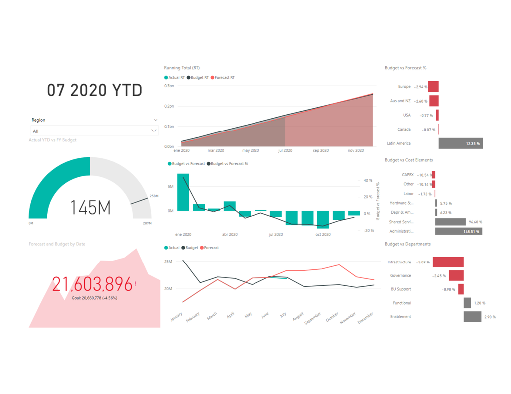

[figure not shown]

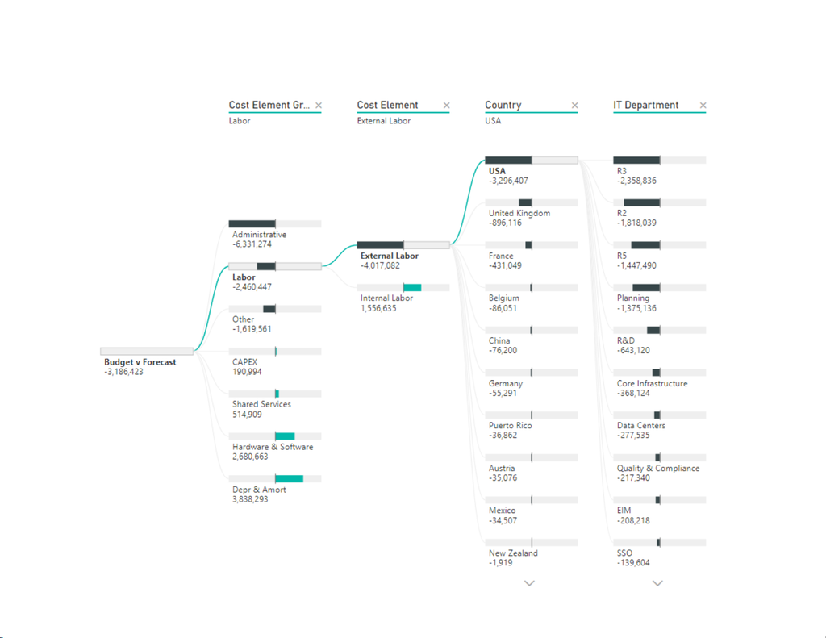